# Churchill_D213_Task2

Briana Churchill

011009463

Dr. William Sewell

2024 May 28

# NLM3 TASK 2: SENTIMENT ANALYSIS USING NEURAL NETWORKS

## Part I: Research Question

### A. Purpose of the data analysis

#### A1. Research question

Can customer sentiment be predicted accurately (70% or higher) using sentiment analysis on the dataset consisting of Imdb, Amazon and Yelp customer reviews?

#### A2. Goals of the data analysis

For this analysis the goal is to use a neural network to predict customer sentiment and compare the predictions to the actual values to determine model accuracy.

#### A3. Type of neural network capable used

The appropriate neural network capable for this analysis with the provided binary data is: Sequence Classification with LSTM RNN.

```python
# Import necessary libraries & packages
import numpy as np
import pandas as pd
import re
from pandas import Series, DataFrame
import matplotlib.pyplot as plt
import warnings
warnings.filterwarnings('ignore')
from sklearn.model_selection import train_test_split
import os
import csv
import tensorflow.keras
from tensorflow.keras.models import Sequential
from tensorflow.keras.preprocessing.text import Tokenizer
from tensorflow.keras.preprocessing.sequence import pad_sequences
from tensorflow.keras.layers import Embedding
from tensorflow.keras import Sequential
from tensorflow.keras.layers import LSTM, Dropout, Dense, Embedding
from tensorflow.keras.callbacks import EarlyStopping
from keras.layers import *
from keras.preprocessing import sequence
import nltk
from nltk.corpus import stopwords
from nltk.tokenize import word_tokenize
from wordcloud import WordCloud, STOPWORDS, ImageColorGenerator
from PIL import Image
from nltk.stem import PorterStemmer
porter=PorterStemmer()
from nltk.stem import WordNetLemmatizer
#import nltk
#nltk.download('wordnet')
#import nltk
#nltk.download('punkt')
```

```python
# Set working directory
# Reference: Dr. Ellah
os.getcwd()
```

```
'C:\\Users\\briana.churchill\\MSDA\\D213\\Task 2'
```

```python
# Read the files
# Reference: Dr. Sewell, Dr. Ellah
amazon = pd.read_csv("amazon_cells_labelled.txt", sep='\t', header=None, names=['review', 'sentiment'], quoting=csv.QUOTE_NONE)
imdb = pd.read_csv("imdb_labelled.txt", sep='\t', header=None, names=['review', 'sentiment'], quoting=csv.QUOTE_NONE)
yelp = pd.read_csv("yelp_labelled.txt", sep='\t', header=None, names=['review', 'sentiment'], quoting=csv.QUOTE_NONE)
# Concatenate them
df = pd.concat((amazon, imdb, yelp), ignore_index=True)
pd.set_option('max_colwidth', 160)
df
```

|  | review | sentiment |
| --- | --- | --- |
| 0 | So there is no way for me to plug it in here in the US unless I go by a converter. | 0 |
| 1 | Good case, Excellent value. | 1 |
| 2 | Great for the jawbone. | 1 |
| 3 | Tied to charger for conversations lasting more than 45 minutes.MAJOR PROBLEMS!! | 0 |
| 4 | The mic is great. | 1 |
| ... | ... | ... |
| 2995 | I think food should have flavor and texture and both were lacking. | 0 |
| 2996 | Appetite instantly gone. | 0 |
| 2997 | Overall I was not impressed and would not go back. | 0 |
| 2998 | The whole experience was underwhelming, and I think we'll just go to Ninja Sushi next time. | 0 |
| 2999 | Then, as if I hadn't wasted enough of my life there, they poured salt in the wound by drawing out the time it took to bring the check. | 0 |

3000 rows × 2 columns

```python
# Review df shape
df.shape
```

```
(3000, 2)
```

```python
# Review df
df.info()
```

```
<class 'pandas.core.frame.DataFrame'>
RangeIndex: 3000 entries, 0 to 2999
Data columns (total 2 columns):
 #   Column     Non-Null Count  Dtype
---  ------     --------------  -----
 0   review     3000 non-null   object
 1   sentiment  3000 non-null   int64
dtypes: int64(1), object(1)
memory usage: 47.0+ KB
```

```python
# Check for missing values
print(df.isnull().sum())
```

```
review       0
sentiment    0
dtype: int64
```

```python
# Confirm 1/2 positive, 1/2 negative reviews as expected
df.sentiment.value_counts()
```

```
sentiment
0    1500
1    1500
Name: count, dtype: int64
```

```python
# Make all letters lowercase
# Reference: Dr. Sewell
df['review'] = df['review'].str.lower()
```

## Part II: Data Preparation

### B. Data cleaning process

#### B1. Exploratory data analysis

#### B1a. Presence of unusual characters

The presence of unusual characters can be seen in step 9 below. These characters were removed in step 10.

```python
# Get list of characters to look for unusual values
# Reference: Dr. Ellah
commentary = df['review']
list_of_characters = []
for comment in commentary:
    for character in comment:
        if character not in list_of_characters:
            list_of_characters.append(character)
print(list_of_characters)
```

```
['s', 'o', ' ', 't', 'h', 'e', 'r', 'i', 'n', 'w', 'a', 'y', 'f', 'm', 'p', 'l', 'u', 'g', 'b', 'c', 'v', '.', 'd', ',', 'x', 'j', '4', '5', '!', 'z', 'q', '+', '"', 'k', "'", '/', '7', '3', '6', '8', '0', '2', '?', '-', '1', ':', ')', '(', '&', '$', '*', ';', '%', '9', '#', '[', ']', '\x96', 'é', '…
```

```python
# Remove punctuation
# Reference: Dr. Sewell
import re
p = re.compile(r'[^\w\s]+')
df['review'] = [p.sub('', x) for x in df['review'].tolist()]
df
```

|  | review | sentiment |
| --- | --- | --- |
| 0 | so there is no way for me to plug it in here in the us unless i go by a converter | 0 |
| 1 | good case excellent value | 1 |
| 2 | great for the jawbone | 1 |
| 3 | tied to charger for conversations lasting more than 45 minutesmajor problems | 0 |
| 4 | the mic is great | 1 |
| ... | ... | ... |
| 2995 | i think food should have flavor and texture and both were lacking | 0 |
| 2996 | appetite instantly gone | 0 |
| 2997 | overall i was not impressed and would not go back | 0 |
| 2998 | the whole experience was underwhelming and i think well just go to ninja sushi next time | 0 |
| 2999 | then as if i hadnt wasted enough of my life there they poured salt in the wound by drawing out the time it took to bring the check | 0 |

3000 rows × 2 columns

#### B1b. Vocabulary size

Seen in step 11, the vocabulary size is 5,402.

```python
# Check vocab size
# Reference: Dr. Ellah
tokenizer = Tokenizer()
tokenizer.fit_on_texts(df['review'])
print("Vocabulary size: ", len(tokenizer.word_index) + 1)
```

```
Vocabulary size:  5402
```

#### B1c. Embedding length

Seen below, the maximum for sequence embedding is 9.

```python
# Get max embedding length
# Reference: Dr. Ellah
vocab_size = 5402
max_sequence_embedding = int(round(np.sqrt(np.sqrt(vocab_size)), 0))
print("Max length of sequence embedding is: ", max_sequence_embedding)
```

```
Max length of sequence embedding is:  9
```

#### B2. Goals of tokenization process

The goals of the tokenization process are:

- To reduce the input vector to be as small as possible by breaking down text into "tokens" or otherwise individual words.
  - Having a lot of large sentence reviews will bog down the analysis process tremendously, making the model run for hours or even days.
- Improve processing time

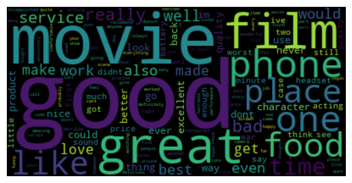

```python
#Create a word cloud
# Reference: Dr. Sewell
import nltk
from nltk.tokenize import word_tokenize
from nltk.corpus import stopwords
from wordcloud import WordCloud, STOPWORDS, ImageColorGenerator # to create a Word Cloud
from PIL import Image # Pillow with WordCloud to image manipulation
# Create stopword list:
stopwords = set(stopwords.words('english'))
stopwords.update(["br", "href"])
textt = " ".join(review for review in df.review)
wordcloud = WordCloud(stopwords=stopwords).generate(textt)
plt.imshow(wordcloud, interpolation='bilinear')
plt.axis("off")
plt.savefig('wordcloud11.png')
plt.show()
```

```python
# Tokenize and vectorize
# Reference: Dr. Sewell
import nltk
from nltk.tokenize import word_tokenize
from nltk.corpus import stopwords
from nltk.stem import PorterStemmer
porter=PorterStemmer()
from keras.layers import *
from tensorflow.keras.preprocessing.text import Tokenizer
from keras.preprocessing import sequence
stop_words = set(stopwords.words('english'))

data_set = []
for sentence in df.review:
    data_set.append([word for word in word_tokenize(sentence) if word not in stop_words])

#print (data_set)
# Word embedding
vocab_size = 5402
# x = df['review']
x = data_set
#print("Tokenized Sentences:",'''\n''',x)
# y = df['rating']
tokenizer = Tokenizer(num_words = vocab_size)
tokenizer.fit_on_texts(x)
x = tokenizer.texts_to_sequences(x)
#print("Vectorized Sentences:",'''\n''',x)
```

```python
# sewell checking dictionary
print(tokenizer.word_index)
```

[output not shown]

```python
# Lemmatize
# Reference: Dr. Sewell
lemmatizer = WordNetLemmatizer()

def lem (token_text):
    text=[lemmatizer.lemmatize(word)for word in token_text]
    return text
```

```python
# lemmatize continued
# Reference: Dr. Sewell
df['review'].apply(lambda x: lem(x))
df['Lemmed_words'] = [len(x.split()) for x in df['review'].tolist()]
df['Lemmed_chars'] = df['review'].apply(len)
df.head(5)
```

|  | review | sentiment | Lemmed_words | Lemmed_chars |
| --- | --- | --- | --- | --- |
| 0 | so there is no way for me to plug it in here in the us unless i go by a converter | 0 | 21 | 81 |
| 1 | good case excellent value | 1 | 4 | 25 |
| 2 | great for the jawbone | 1 | 4 | 21 |
| 3 | tied to charger for conversations lasting more than 45 minutesmajor problems | 0 | 11 | 76 |
| 4 | the mic is great | 1 | 4 | 16 |

```python
# Max length of lemmed_words
df.Lemmed_words.max()
```

```
70
```

### B3. Padding process

#### B3a. When the padding occurs

Padding is adding zeros in the beginning or end of a sequence to meet a specific length for all the sequences. Using the pad_sequences module and maximum length of 70 (max lemmed words), padding was performed after each sequence until all sequences had a length of 70. Padding is vital because it makes all the sentences the same length which is necessary for a tensor flow to function properly. See the padding process used below:

```python
# Padding
# Reference: Dr. Sewell
from tensorflow.keras.preprocessing.sequence import pad_sequences
max_length = 70
padded_reviews = pad_sequences(x, maxlen = max_length, padding = 'post', truncating = 'post')
print(padded_reviews.shape)
```

```
(3000, 70)
```

#### B3b. Screenshot of a single padded sequence

Printed below is what sequence 417 looks like. There are 5 original values and the rest are all zeros, which shows the padding was successful and now this sequence has a length of 70.

```python
# Single padded sequence
print(padded_reviews[417])
```

```
[  44    4   25 1447   26    0    0    0    0    0    0    0    0    0
    0    0    0    0    0    0    0    0    0    0    0    0    0    0
    0    0    0    0    0    0    0    0    0    0    0    0    0    0
    0    0    0    0    0    0    0    0    0    0    0    0    0    0
    0    0    0    0    0    0    0    0    0    0    0    0    0    0]
```

#### B4. How many categories of sentiment will be used and activation function

There are two categories of sentiment which can be seen below. There are positive (1) and negative (0). Because there are only two categories, binary classification will be used in the final model which means the activation function for the final dense layer of the network should be sigmoid.

```python
# Show # of sentiment categories
df.sentiment.value_counts()
```

```
sentiment
0    1500
1    1500
Name: count, dtype: int64
```

#### B5. Explain the steps used to prepare the data for analysis

The steps used to prepare the data are all of the steps seen above, which are:

- Setting the working directory
  - To ensure the datasets can be imported
- Import all three datasets and concat them into a data frame
- Review the data frame info and shape to become familiar with it and confirm all data was imported correctly
- Check for null values
- Check sentiment values to confirm half are positive and half are negative as expected
- Make all values lowercase
- Look for and remove special characters/punctuation
- Check vocabulary size
- Obtain the max embedding length
- Create a word cloud
- Tokenize and vectorize which includes embedding
- check word_index to ensure accurate implementation
- Lemmatize words
- Obtain max length of lemmed_words
- Perform padding
- Review random padded sequence to ensure accurate implementation
- Split the data set
  - Using train_test_split with a test size of 20% to ensure an adequate amount is trained
  - Padded reviews = x, df.sentiment = y
- Review shape of X_Train for review to ensure accuracy

```python
#Split the dataset
X_train, X_test, y_train, y_test = train_test_split(padded_reviews, df.sentiment, test_size=0.20, random_state=42)
```

```python
# Review train split
X_train.shape
```

```
(2400, 70)
```

#### B6. Provide a copy of the prepared data set.

Seen below are all the scripts used to save the train/test data and the whole prepared data set, all of which will be included in the submission for this assessment.

```python
# Save each data set to CSV
X_train_df = pd.DataFrame(X_train)
X_test_df = pd.DataFrame(X_test)
y_train_df = pd.DataFrame(y_train)
y_test_df = pd.DataFrame(y_test)
X_train_df.to_csv('X_train.csv', index=False)
X_test_df.to_csv('X_test.csv', index=False)
y_train_df.to_csv('y_train.csv', index=False)
y_test_df.to_csv('y_test.csv', index=False)
fdf = pd.DataFrame(padded_reviews)
fdf['sentiment'] = df.sentiment
fdf.to_csv('prepared_data.csv')
```

### Part III: Network Architecture

#### C1. Model summary

See below the model and model summary.

```python
# Build, compile and fit the model
# Reference: Dr. Sewell
vocab_size = 5402
embed_size = 9
model = Sequential()
model.add(Embedding(vocab_size, embed_size, input_shape = (X_train.shape[1],)))
model.add(LSTM(units=60, activation='tanh'))
model.add(Dense(units=1, activation='sigmoid'))

model.compile(optimizer='adam', loss='binary_crossentropy', metrics=['accuracy'])

early_stopping_monitor = EarlyStopping(patience=2)
history = model.fit(X_train, y_train, epochs = 5, batch_size = 32, validation_data=(X_test, y_test))
```

```
75/75 ━━━━━━━━━━━━━━━━━━━━ 2s 16ms/step - accuracy: 0.5048 - loss: 0.6933 - val_accuracy: 0.5017 - val_loss: 0.6931
75/75 ━━━━━━━━━━━━━━━━━━━━ 1s 13ms/step - accuracy: 0.4760 - loss: 0.6934 - val_accuracy: 0.5017 - val_loss: 0.6931
75/75 ━━━━━━━━━━━━━━━━━━━━ 1s 15ms/step - accuracy: 0.4931 - loss: 0.6932 - val_accuracy: 0.4983 - val_loss: 0.6932
75/75 ━━━━━━━━━━━━━━━━━━━━ 1s 16ms/step - accuracy: 0.4796 - loss: 0.6933 - val_accuracy: 0.4983 - val_loss: 0.6932
75/75 ━━━━━━━━━━━━━━━━━━━━ 1s 14ms/step - accuracy: 0.5108 - loss: 0.6931 - val_accuracy: 0.5017 - val_loss: 0.6931
```

```python
# Get model summary
model.summary()
```

```
Model: "sequential"
```

```
┏━━━━━━━━━━━━━━━━━━━━━━━━━━━━━━━━━┳━━━━━━━━━━━━━━━━━━━━━━━━┳━━━━━━━━━━━━━━━┓
┃ Layer (type)                    ┃ Output Shape           ┃       Param # ┃
┡━━━━━━━━━━━━━━━━━━━━━━━━━━━━━━━━━╇━━━━━━━━━━━━━━━━━━━━━━━━╇━━━━━━━━━━━━━━━┩
│ embedding (Embedding)           │ (None, 70, 9)          │        48,618 │
├─────────────────────────────────┼────────────────────────┼───────────────┤
│ lstm (LSTM)                     │ (None, 60)             │        16,800 │
├─────────────────────────────────┼────────────────────────┼───────────────┤
│ dense (Dense)                   │ (None, 1)              │            61 │
└─────────────────────────────────┴────────────────────────┴───────────────┘
```

```
 Total params: 196,439 (767.34 KB)
```

```
 Trainable params: 65,479 (255.78 KB)
```

```
 Non-trainable params: 0 (0.00 B)
```

```
 Optimizer params: 130,960 (511.57 KB)
```

#### C2. Discuss the number of layers, the type of layers, and the total number of parameters.

There are three layers in the sequential model:

- Embedding
  - Embedding length of 70
  - 48,618 parameters
- LSTM (Long Short Term Memory)
  - Learns order dependence and patterns to make predictions
  - 16,800 parameters
- Dense
  - Fully connected layer
  - Parameters: 61

```python
# Verify model accuracy
# Reference: Dr. Ellah
score = model.evaluate(X_test, y_test, verbose=0)
print(f'Test loss: {score[0]} / Test accuracy: {score[1]}')
```

```
Test loss: 0.6931461691856384 / Test accuracy: 0.5016666650772095
```

## Part IV: Model Evaluation

### D. Evaluate the model training process

#### D3. Provide visualizations of the model’s training process, including a line graph of the loss and chosen evaluation metric.

See the model accuracy viz below, along with the model loss. As one can tell off the visualizations alone, the train data set is not close in accuracy as compared to the actual review values. The evaluation metric described and shown at C3 can be seen again under the visualizations as well.

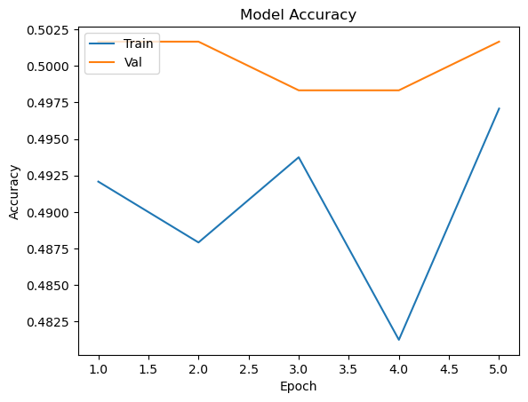

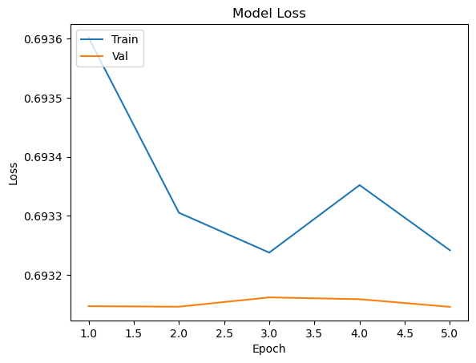

```python
# Create viz's for model accuracy and model loss
# Reference: Dr. Sewell
def plot_learningCurve(history, epochs):
    epoch_range = range(1, epochs+1)
    plt.plot(epoch_range, history.history['accuracy'])
    plt.plot(epoch_range, history.history['val_accuracy'])
    plt.title('Model Accuracy')
    plt.ylabel('Accuracy')
    plt.xlabel('Epoch')
    plt.legend(['Train', 'Val'], loc='upper left')
    plt.show()
    plt.plot(epoch_range, history.history['loss'])
    plt.plot(epoch_range, history.history['val_loss'])
    plt.title('Model Loss')
    plt.ylabel('Loss')
    plt.xlabel('Epoch')
    plt.legend(['Train', 'Val'], loc='upper left')
    plt.show()
plot_learningCurve(history, 5)
```

```python
# Verify model accuracy
# Reference: Dr. Ellah
score = model.evaluate(X_test, y_test, verbose=0)
print(f'Test loss: {score[0]} / Test accuracy: {score[1]}')
```

```
Test loss: 0.6931461691856384 / Test accuracy: 0.5016666650772095
```

#### D4. Discuss the predictive accuracy of the trained network using the chosen evaluation metric from part D3.

Overall, this predictive accuracy of the trained network is not optimal.

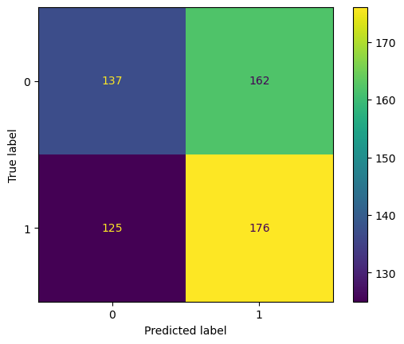

```python
# Predictive accuracy
# Reference: Dr. Sewell
import matplotlib.pyplot as plt
from sklearn.datasets import make_classification
from sklearn.metrics import confusion_matrix, ConfusionMatrixDisplay
from sklearn.svm import SVC
clf = SVC(random_state=0)
clf.fit(X_train, y_train)
SVC(random_state=0)
predictions = clf.predict(X_test)
cm = confusion_matrix(y_test, predictions, labels=clf.classes_)
disp = ConfusionMatrixDisplay(confusion_matrix=cm, display_labels=clf.classes_)
disp.plot()
plt.show()
```

### Part V: Summary and Recommendations

#### E. Provide the code you used to save the trained network within the neural network.

Please see the code used below.

```python
# Save trained network
model.save('C:\\Users\\briana.churchill\\MSDA/model.keras')
```

#### F. Discuss the functionality of your neural network, including the impact of the network architecture.

The neural network is not functional at this point in time. It only predicts accurately about 50% of the time, which could be done with a simple coin toss. Even though the model was not overfitted, there may need to be additional changes made within the parameters to produce a more reliable model.

#### G. Recommend a course of action based on your results.

It is recommended that the current neural network is not to be used with the provided data sets to make sentiment predictions. Instead, it is best to reassess and make changes to the model. Specifically testing out different parameters such as the number of nodes, epochs, and input length until a more accurate model is created.

## Part VI: Reporting

#### H. Show your neural network in an industry-relevant interactive development environment (e.g., a Jupyter Notebook). Include a PDF or HTML document of your executed notebook presentation.

The analysis and write up were all done within Jupyter Notebook, and is attached to the submission as an HTML file.

#### I. Sources

Ellah, F. (n.d). Unpublished D213 T2 webinar. Western Governors University. Sewell, W. (n.d). D213 Webinar IV, V & VI for task two. Western Governors University. Peixeiro, M. (2019, Feb 21). Step-by-step Guide to Building Your Own Neural Network From Scratch. Retrieved from: https://towardsdatascience.com/step-by-step-guide-to-building-your-own-neural-network-from-scratch-df64b1c5ab6e Getting started with the Keras Sequential model. Retrieved from: https://faroit.com/keras-docs/1.0.1/getting-started/sequential-model-guide/ Understanding LSTM for Sequence Classification: A Practical Guide with PyTorch. Retrieved from: https://medium.com/@hkabhi916/understanding-lstm-for-sequence-classification-a-practical-guide-with-pytorch-ac40e84ad3d5 Furnieles, G. 2022, Sep 8). Sigmoid and SoftMax Functions in 5 minutes. Retrieved from: https://towardsdatascience.com/sigmoid-and-softmax-functions-in-5-minutes-f516c80ea1f9 Padding for NLP. Retrieved from: https://medium.com/@canerkilinc/padding-for-nlp-7dd8598c916a